# Justin Gausin HW 2 (BDA 401-501) due date: 11:59 pm EST 10.06.2022

# Load Libraries

```r
library(tidyverse)
library(dplyr)
library(lubridate)
library(ggrepel)
```

```r
covid <- read_csv(file =
"https://data.virginia.gov/api/views/bre9-aqqr/rows.csv?accessType=DOWNLOAD")
```

1. Extractracting the Covid data for 4 cities Norfolk, Virginia Beach, Chesapeake, Portsmouth into a dataset named four_city.

```r
cities <- c("Norfolk", "Virginia Beach", "Chesapeake", "Portsmouth")
four_city <- covid %>%
  filter(Locality %in% cities)

dim(four_city)
```

```
## [1] 3824    7
```

2. Plotting the total number of deaths by day for four cities in the same graph.

The *combined* total death of the four cities is shown below:

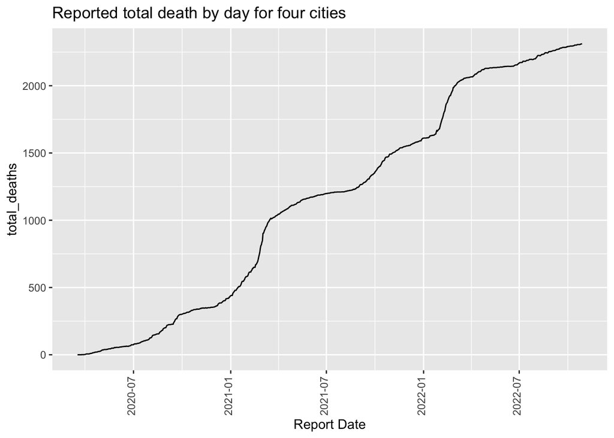

```r
totaldeath_byday <- four_city %>%
  mutate(`Report Date` = mdy(four_city$`Report Date`)) %>%
  group_by(`Report Date`) %>%
  summarise(total_deaths = as.integer(sum(`Deaths`))) %>%
  ggplot() +
  geom_line(mapping = aes(x =`Report Date`, y = total_deaths)) +
  theme(axis.text.x = element_text(angle=90, v=.2)) +
  labs(title="Reported total death by day for four cities")

totaldeath_byday
```

We can further divide the dataset into *each* of the four cities. Below is the total death by day for each of the four cities:

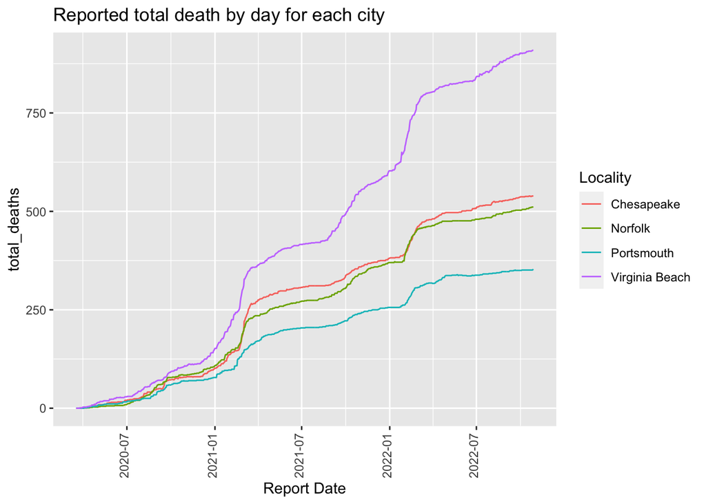

```r
death_byday23 <- four_city %>%
  mutate(`Report Date` = mdy(four_city$`Report Date`)) %>%
  group_by(`Locality`,`Report Date`) %>%
  summarise(total_deaths = as.integer(sum(`Deaths`))) %>%
  ggplot() +
  geom_line(mapping = aes(x =`Report Date`, y = total_deaths, color=Locality)) +
  theme(axis.text.x = element_text(angle=90, v=.2)) +
  labs(title="Reported total death by day for each city")

death_byday23
```

3. Plotting the proportion of total number of deaths over the hospitalization for four cities n the same graph. The *combined* total death of the four cities is shown below:

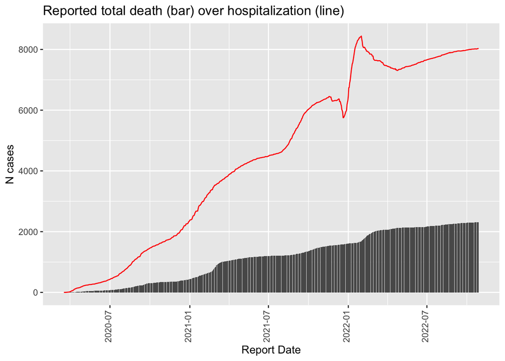

```r
totaldeath_byday <- four_city %>%
  mutate(`Report Date` = mdy(four_city$`Report Date`)) %>%
  group_by(`Report Date`) %>%
  summarise(total_deaths = as.integer(sum(`Deaths`)),
            total_hospit = as.integer(sum(`Hospitalizations`))) %>%
  mutate(lagHospital = total_hospit - lag(total_hospit)) %>%
  ggplot(mapping=aes(x=`Report Date`)) +
  geom_col(mapping = aes(y = total_deaths)) +
  geom_line(mapping= aes(y = total_hospit), show.legend = TRUE , color = "red") +
  theme(axis.text.x = element_text(angle=90, v=.2)) +
  labs(title="Reported total death (bar) over hospitalization (line)", y ="N cases")

totaldeath_byday
```

# Community Policing Data (70 points)

We will doing some analysis based on a data collection consisting of all traffic and investigatory stops made in Virginia as aggregated by Virginia Department of State Police. You can download the data set from here https://data.virginia.gov/Public-Safety/Community-Policing-Data-July-1-2020-to-May-31-2022/2c96-texw using this R code

```r
police <- read_csv(file = "https://data.virginia.gov/api/views/2c96-texw/rows.csv?accessType=DOWNLOAD")
```

The dimension of the following data set:

```r
dim(police)
```

```
## [1] 1882854      20
```

Each variable(features) of the data set is described as:

| Column Name | Description Type |
| --- | --- |
| INCIDENT DATE | Indicates the date of the motor vehicle stop |
| AGENCY NAME | Name of law enforcement agency |
| JURISDICTION | Location of stop by city or county |
| REASON FOR STOP | Indicates the initial reason for the motor vehicle/traffic stop |
| PERSON TYPE | Indicates whether the person subject to the investigative detention stop is a Driver, Passenger, or Pedestrian/Individual |
| RACE | Indicates the race of the Driver/Individual involved |
| ETHNICITY | Indicates the ethnicity of the Driver/Individual involved |
| AGE | Indicates the age of the Driver/Individual involved |
| GENDER | Indicates the gender of the Driver/Individual involved |
| ENGLISH SPEAKING | Indicates if the Driver/Individual speaks English |
| ACTION TAKEN | Indicates the most serious action taken towards the Driver/Individual at the completion of the stop or as a result of the stop |
| VIOLATION TYPE | Indicates if the violation was a local or commonwealth code (no longer collected as of July 1, 2021) |
| SPECIFIC VIOLATION | Indicates the specific code section in connection with action taken |
| VIRGINIA CRIME CODE | Indicates corresponding Virginia Crime Code (Optional) |
| PERSON SEARCHED? | Indicates if the Driver/Individual was searched as a result of the stop |
| VEHICLE SEARCHED? | Indicates if the vehicle was searched as a result of the stop |
| ADDITIONAL ARREST? | Indicates a person OTHER THAN THE DRIVER was arrested as a result of the stop. (no longer collected as of July 1, 2021) |
| PHYSICAL FORCE BY OFFICER | Indicates if the law-enforcement officer or State Police officer used physical force against the person |
| PHYSICAL FORCE BY SUBJECT | Indicates if the subject used physical force against any officers |
| RESIDENCY | Indicates the residency of the subject stopped |

2.Using ggplot2 to make a bar chart for total stops of these locations, mapping ACTION TAKEN to the color of the bar chart.

Finding the top 20 counties/cities in VA with the most stops:

```r
 total_20_stops <- police %>%
  count(`JURISDICTION`) %>%
  arrange(desc(n)) %>%
  head(20)
cat("The top 20 JURISDICTION based on # of stops over VA are: \n")
```

```
## The top 20 JURISDICTION based on # of stops over VA are:
```

```r
total_20_stops
```

| JURISDICTION | n |
| --- | --- |
| FAIRFAX CO | 93596 |
| CHESTERFIELD CO | 82129 |
| HENRICO CO | 81047 |
| VIRGINIA BEACH | 80113 |
| PRINCE WILLIAM CO | 67811 |
| LOUDOUN CO | 57050 |
| BRUNSWICK CO | 45729 |
| CHESAPEAKE | 42523 |
| ARLINGTON CO | 40694 |
| NORTHAMPTON CO | 40343 |

[output cut: 10 more lines]

We then filter the data set to only include the top 20 jurisdictions:

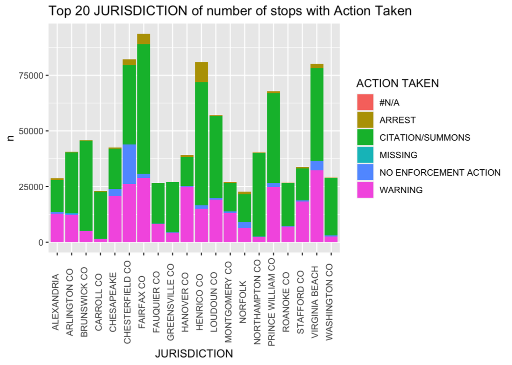

```r
#Filter the data with the top 20 stops
to_graph_stops <- police %>%
  filter(JURISDICTION %in%  total_20_stops$JURISDICTION) %>%
  group_by(JURISDICTION, `ACTION TAKEN`) %>%
  summarise(n=n()) %>%
  ggplot(aes(fill=`ACTION TAKEN`)) +
  geom_bar(aes(x=JURISDICTION, y = n), stat="identity") +
  theme(axis.text.x = element_text(angle=90, v=.2)) +
  labs(title="Top 20 JURISDICTION of number of stops with Action Taken")

to_graph_stops
```

3. Using ggplot2 to make a bar chart with decreasing order of the number of stops for each reason.

The percentage of the initial reasons for stops:

```r
init_reasons <- police %>%
  count(`REASON FOR STOP`, sort=TRUE) %>%
  mutate(freq= ((n/sum(n)) * 100)) %>%
  arrange(desc(n))

init_reasons
```

| REASON FOR STOP | n | freq |
| --- | --- | --- |
| TRAFFIC VIOLATION | 1610616 | 85.5412050 |
| EQUIPMENT VIOLATION | 159414 | 8.4666150 |
| OTHER | 39303 | 2.0874162 |
| CALLS FOR SERVICE | 33708 | 1.7902610 |
| MISSING | 21880 | 1.1620657 |
| TERRY STOP | 13903 | 0.7384003 |
| CHECK POINT | 4030 | 0.2140368 |

The number of stops for each reasons:

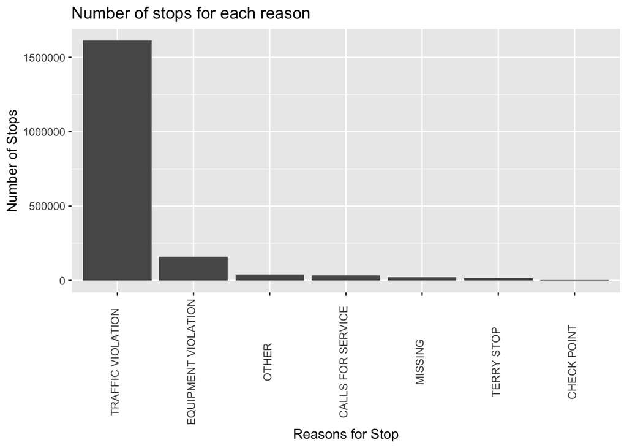

```r
init_reasons %>% ggplot() +
  geom_col(mapping=aes(x=reorder(`REASON FOR STOP`, - n), y=n)) +
  theme(axis.text.x = element_text(angle=90, v=.2))  +
  labs(title="Number of stops for each reason", x="Reasons for Stop", y="Number of Stops")
```

4. Using ggplot2 to make a plot number of stops by date all over Virginia.

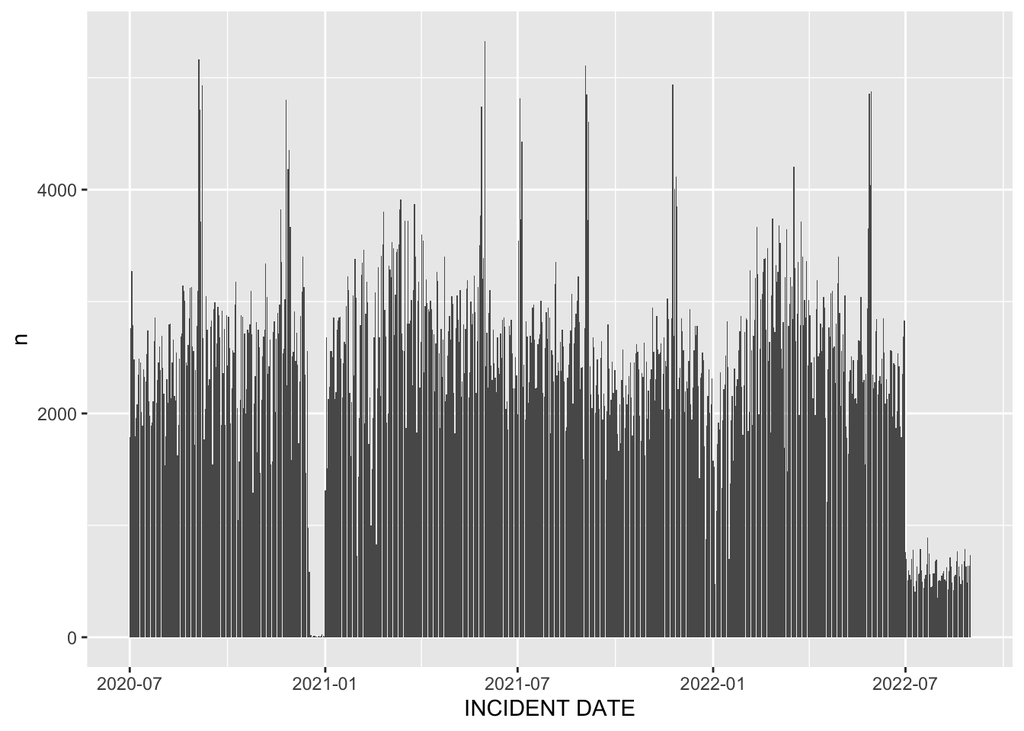

```r
stops_by_date <- police %>%
  mutate(`INCIDENT DATE` = as.Date(mdy_hms(police$`INCIDENT DATE`))) %>%
  count(`INCIDENT DATE`, sort=TRUE) %>%
  ggplot() +
  geom_col(mapping = aes(x=`INCIDENT DATE`, y = n))


stops_by_date
```

5. Using ggplot2 make a histogram of stops by age.

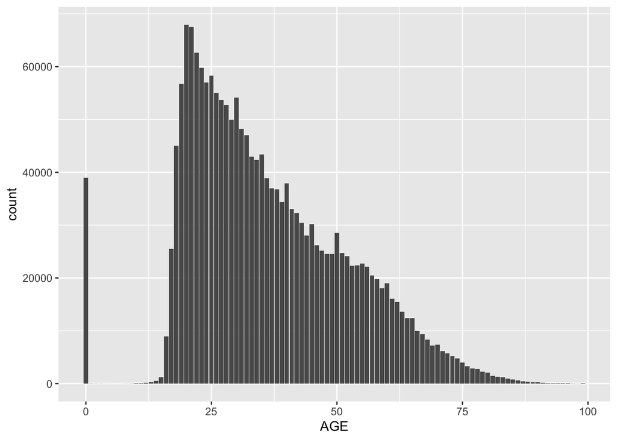

```r
ggplot(data = police) +
  geom_bar(mapping = aes(x=AGE))
```

```r
stops <- police[police$AGE == 0,]
cat("There are about", nrow(stops), "age misrepresented as 0's in the data set")
```

```
## There are about 38944 age misrepresented as 0's in the data set
```

6. Using ggplot2 to create a pie chart of the stops by RACE, and labeling each piece of the chart by the percentage of the stops for each RACE.

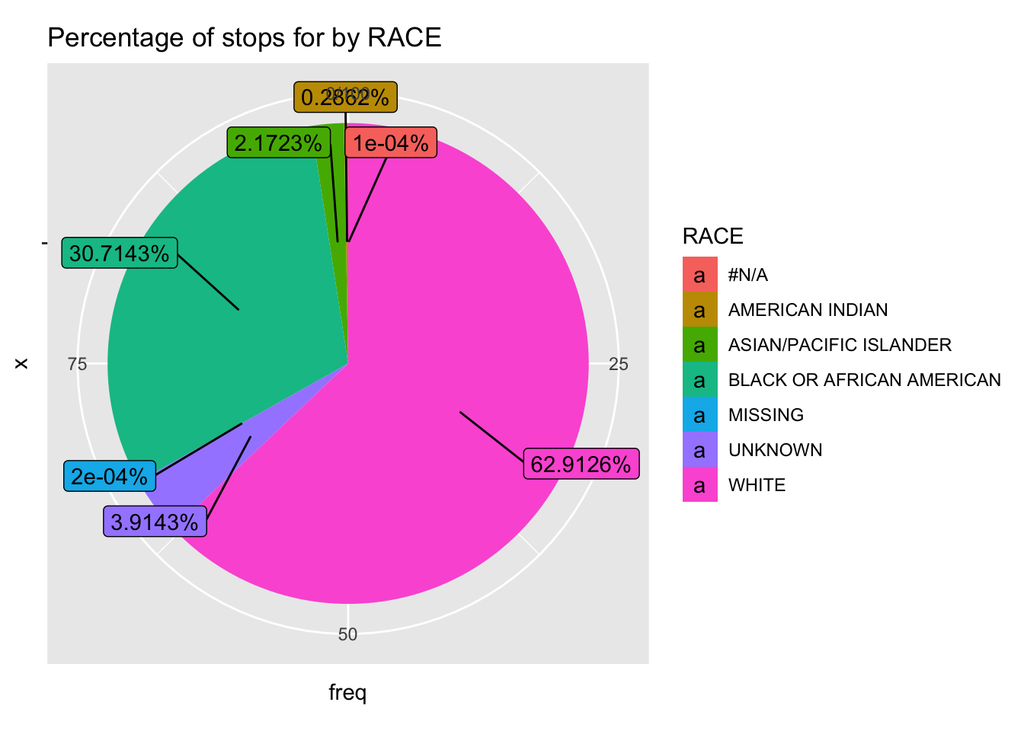

```r
stops_by_Race <- police %>%
  count(`RACE`) %>%
  mutate(freq = round((n/sum(n) * 100), digits=4)) %>%
  mutate(cs = rev(cumsum(rev(freq))),
         pos = freq/2 + lead(cs,1),
         pos = if_else(is.na(pos), freq/2, pos)) %>%
  ggplot(mapping=aes(x="", y=freq, fill=RACE)) +
  geom_col() +
  geom_label_repel(aes(label=paste0(freq, "%"), y=pos),
                   force=.5, nudge_x = .5) +
  coord_polar(theta="y") +
  labs(title="Percentage of stops for by RACE")

stops_by_Race
```

7. Using ggplot2 to create a pie chart of the stops by GENDER, and labeling each piece of the chart by the percentage of the stops for each GENDER.

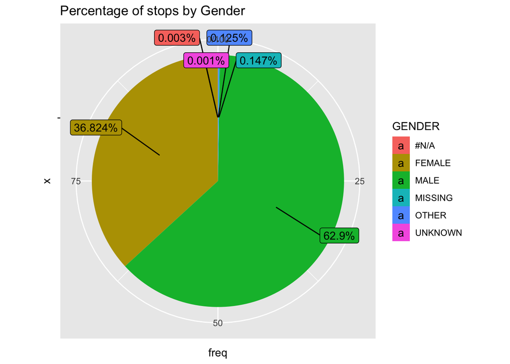

```r
stops_by_Gender  <- police %>%
  count(`GENDER`) %>%
  mutate(freq= round(n/sum(n)*100, digits=3)) %>%
  mutate(cs = rev(cumsum(rev(freq))),
         pos = freq/2 + lead(cs,1),
         pos = if_else(is.na(pos), freq/2, pos)) %>%
  ggplot(mapping=aes(x="", y=freq, fill=GENDER)) +
  geom_col() +
  geom_label_repel(aes(label=paste0(freq, "%"), y=pos),
                   force=.5, nudge_x = .5) +
  coord_polar(theta="y") +
  labs(title="Percentage of stops by Gender")

stops_by_Gender
```

8. Using ggplot2 to create a stack bar chart for the number of stops by GENDER, stacked by ACTION TAKEN.

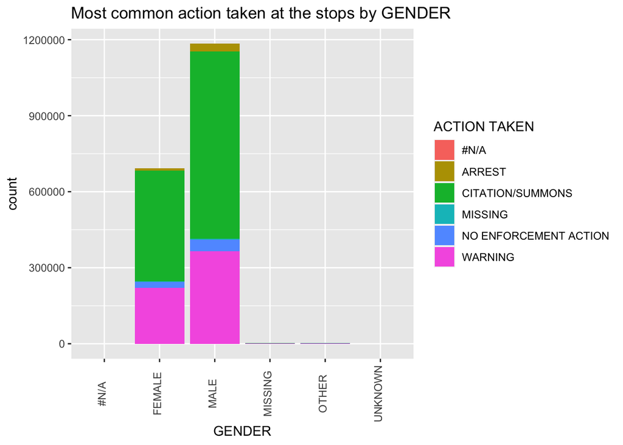

```r
gender_stops <- police %>%
  group_by(`GENDER`) %>%
  ggplot() +
  geom_bar(mapping=aes(x=`GENDER`, fill=`ACTION TAKEN`)) +
  theme(axis.text.x = element_text(angle=90, v=.2)) +
  labs(title="Most common action taken at the stops by GENDER")

gender_stops
```

A majority of the Action Taken, regardless of Gender, is **Citations/Summons**. The second most ACTION TAKEN is **Warning**.